# ~ Project 4 ~

# Wrangle and Analyze Data

## Analysis and reporting by Audrey Tan

- 1. Project Introduction
- 2. Data Wrangling
  - 2.1 Data Gathering
  - 2.2 Data Assessing
  - 2.3 Data Cleansing Tasks
  - 2.4 Data Cleaning
  - 2.5 Data Storing
- 3. Data Analysis and Visualisation
  - 3.1 Visualization 1 and Data Insight 1
  - 3.2 Visualization 2 and Data Insight 2
  - 3.3 Visualization 3 and Data Insight 3
- 4. Conclusion

## 2. Data Wrangling

This process entails the following:

> - Gather the 3 required datasets from different sources load into 3 dataframes
> - Inspect the 3 dataframes visually and programmatically to assess the tidiness and quality of the data
> - Compose a data cleaning do-do list from assessment results for use in Data Cleansing

```python
import numpy as np
import pandas as pd
import matplotlib.pyplot as plt
import seaborn as sb
from IPython.display import Image
import re
import os
import requests as req
import json
import tweepy
from timeit import default_timer as timer
from sqlalchemy import create_engine
%matplotlib inline
```

### 2.1 Data Gathering

### Read [twitter_archive_enhanced.csv](https://d17h27t6h515a5.cloudfront.net/topher/2017/August/59a4e958_twitter-archive-enhanced/twitter-archive-enhanced.csv) and load into dataframe

```python
twdf = pd.read_csv('twitter_archive_enhanced.csv')
twdf.head(2)
```

|  | tweet_id | in_reply_to_status_id | in_reply_to_user_id | timestamp | source | text | retweeted_status_id | retweeted_status_user_id | retweeted_status_timestamp | expanded_urls | rating_numerator | rating_denominator | name | doggo | floofer | pupper | puppo |
| --- | --- | --- | --- | --- | --- | --- | --- | --- | --- | --- | --- | --- | --- | --- | --- | --- | --- |
| 0 | 892420643555336193 | NaN | NaN | 2017-08-01 16:23:56 +0000 | <a href="http://twitter.com/download/iphone" r... | This is Phineas. He's a mystical boy. Only eve... | NaN | NaN | NaN | https://twitter.com/dog_rates/status/892420643... | 13 | 10 | Phineas | None | None | None | None |
| 1 | 892177421306343426 | NaN | NaN | 2017-08-01 00:17:27 +0000 | <a href="http://twitter.com/download/iphone" r... | This is Tilly. She's just checking pup on you.... | NaN | NaN | NaN | https://twitter.com/dog_rates/status/892177421... | 13 | 10 | Tilly | None | None | None | None |

### Read image-predictions.tsv and load into dataframe

```python
url = 'https://d17h27t6h515a5.cloudfront.net/topher/2017/August/599fd2ad_image-predictions/image-predictions.tsv'
try:
    res = req.get(url)
except Exception as e:
    print(e)

with open('image_predictions.tsv', mode = 'wb') as file:
    file.write(res.content)

imgdf = pd.read_csv('image_predictions.tsv', sep = '\t')
```

```python
imgdf.head(2)
```

|  | tweet_id | jpg_url | img_num | p1 | p1_conf | p1_dog | p2 | p2_conf | p2_dog | p3 | p3_conf | p3_dog |
| --- | --- | --- | --- | --- | --- | --- | --- | --- | --- | --- | --- | --- |
| 0 | 666020888022790149 | https://pbs.twimg.com/media/CT4udn0WwAA0aMy.jpg | 1 | Welsh_springer_spaniel | 0.465074 | True | collie | 0.156665 | True | Shetland_sheepdog | 0.061428 | True |
| 1 | 666029285002620928 | https://pbs.twimg.com/media/CT42GRgUYAA5iDo.jpg | 1 | redbone | 0.506826 | True | miniature_pinscher | 0.074192 | True | Rhodesian_ridgeback | 0.072010 | True |

### Call Twitter API to pratice gathering of additional twitter data and loading into dataframe. However, *do not* use this dataframe for data assessing (since it does not have all the tweet details corresponding to the tweet ids in [twitter_archive_enhanced.csv](https://d17h27t6h515a5.cloudfront.net/topher/2017/August/59a4e958_twitter-archive-enhanced/twitter-archive-enhanced.csv) . Use the Udacity provided [tweet_json.txt](https://s3.amazonaws.com/video.udacity-data.com/topher/2018/November/5be5fb7d_tweet-json/tweet-json.txt) instead (see details in the next cell down).

### For project submission, set Twitter API keys to '*'

```python
# For project submission, set api keys to '*'
# setup twitter api auth

consumer_key = '*'
consumer_secret = '*'
access_token = '*'
access_secret = '*'

for k in [consumer_key, consumer_secret, access_token, access_secret]:
    skip = False if len(k) > 1 else True

if skip:
    print('In project submission ... skip Twitter API Call practice')
else:
    auth = tweepy.OAuthHandler(consumer_key, consumer_secret)
    auth.set_access_token(access_token, access_secret)

    api = tweepy.API(auth_handler=auth,
                 wait_on_rate_limit= True,
                 wait_on_rate_limit_notify=True)

    print_ok = 100
    print_err = 4
    # get all the tweet ids from twdf (twitter_archive_enhanced.csv)
    twids = twdf.tweet_id.values

    # start reading
    start = timer()
    tw_dict = {}
    baddict = {}
    cnt = 0

    for id in twids:
        cnt +=1
        try:
            txt = api.get_status(id, tweet_mode='extended')
            # convert id to str as json.dump require dict key to be string
            tw_dict[str(id)] = txt._json
            if cnt % print_ok == 0:
                print('Success:{}-{}'.format(cnt, id))
        except tweepy.TweepError as e:
            baddict[str(id)] = e
            if cnt % print_err == 0:
                print('tweepErr:{}-{}'.format(id, e))
            pass

    elapsed = timer() - start
    print('\nTwitter read done. Total elapsed time: {} minutes'.format(elapsed/60))

    with open('twt2_json.txt', 'w') as outfile:
        json.dump(tw_dict, outfile,
                  ensure_ascii = True,
                  sort_keys = True,
                  indent=4)

    twtdf = pd.read_json('twt2_json.txt',orient='index')
    print('\ntwtdf.shape:', twtdf.shape)
    twtdf.to_csv('twt_df.csv', index = False)

    print('\ntweepErr dict:\n',baddict)
    baddf=pd.DataFrame(list(baddict.items()), columns=['twid', 'msg'])
    print('\nbaddf.shape:', baddf.shape, '\n')
    baddf.to_csv('tweet_nodat.csv', index = False)
    baddf
```

[output not shown]

```
Rate limit reached. Sleeping for: 786
```

```
Success:900-758828659922702336
Success:1000-748220828303695873
Success:1100-735991953473572864
Success:1200-716791146589110272
Success:1300-707738799544082433
Success:1400-699691744225525762
Success:1500-692187005137076224
Success:1600-686034024800862208
Success:1700-680970795137544192
```

```
Rate limit reached. Sleeping for: 785
```

```
Success:1800-677187300187611136
Success:1900-674670581682434048
Success:2000-672523490734551040
Success:2100-670717338665226240
Success:2200-668779399630725120
Success:2300-667065535570550784

Twitter read done. Total elapsed time: 31.329648029016486 minutes

twtdf.shape: (2337, 32)

tweepErr dict:
 {'888202515573088257': TweepError([{'code': 144, 'message': 'No status found with that ID.'}],), '873697596434513921': TweepError([{'code': 144, 'message': 'No status found with that ID.'}],), '872668790621863937': TweepError([{'code': 144, 'message': 'No status found with that ID.'}],), '872261713…

baddf.shape: (19, 2)
```

### The Udacity provided [tweet_json.txt](https://s3.amazonaws.com/video.udacity-data.com/topher/2018/November/5be5fb7d_tweet-json/tweet-json.txt) was gathered using the following code:

```
import tweepy
from tweepy import OAuthHandler
import json
from timeit import default_timer as timer

# Query Twitter API for each tweet in the Twitter archive and save JSON in a text file
# These are hidden to comply with Twitter's API terms and conditions
consumer_key = 'HIDDEN'
consumer_secret = 'HIDDEN'
access_token = 'HIDDEN'
access_secret = 'HIDDEN'

auth = OAuthHandler(consumer_key, consumer_secret)
auth.set_access_token(access_token, access_secret)

api = tweepy.API(auth, wait_on_rate_limit=True)

# NOTE TO STUDENT WITH MOBILE VERIFICATION ISSUES:
# df_1 is a DataFrame with the twitter_archive_enhanced.csv file. You may have to
# change line 17 to match the name of your DataFrame with twitter_archive_enhanced.csv
# NOTE TO REVIEWER: this student had mobile verification issues so the following
# Twitter API code was sent to this student from a Udacity instructor
# Tweet IDs for which to gather additional data via Twitter's API
tweet_ids = df_1.tweet_id.values
len(tweet_ids)

# Query Twitter's API for JSON data for each tweet ID in the Twitter archive
count = 0
fails_dict = {}
start = timer()
# Save each tweet's returned JSON as a new line in a .txt file
with open('tweet_json.txt', 'w') as outfile:
    # This loop will likely take 20-30 minutes to run because of Twitter's rate limit
    for tweet_id in tweet_ids:
        count += 1
        print(str(count) + ": " + str(tweet_id))
        try:
            tweet = api.get_status(tweet_id, tweet_mode='extended')
            print("Success")
            json.dump(tweet._json, outfile)
            outfile.write('\n')
        except tweepy.TweepError as e:
            print("Fail")
            fails_dict[tweet_id] = e
            pass
end = timer()
print(end - start)
print(fails_dict)
```

### Read [tweet_json.txt](https://s3.amazonaws.com/video.udacity-data.com/topher/2018/November/5be5fb7d_tweet-json/tweet-json.txt) and load into dataframe. Entries pertaining to re-tweets or reply to tweets should not be loaded given the focus is on original tweets.

```python
tw2df = pd.DataFrame(columns = ['tweet_id', 'retwt_cnt', 'fav_cnt'])

# open the TXT file programmatically
with open('tweet_json.txt') as f:
    for line in f:
        # load its contents line by line, i.e. JSON object by JSON object
        twt = json.loads(line)
        # skip retweet or reply to tweet
        if ((twt['in_reply_to_status_id'] == None) & (twt['in_reply_to_user_id'] == None)):
            id_str = twt['id_str']
            retwt_cnt = twt['retweet_count']
            fav_cnt = twt['favorite_count']

            # store the additional needed information into a dataframe
            tw2df = tw2df.append({'tweet_id' : id_str,
                                  'retwt_cnt' : retwt_cnt,
                                  'fav_cnt' : fav_cnt},
                                  ignore_index = True)
        else:
            continue


tw2df.head(2)
```

|  | tweet_id | retwt_cnt | fav_cnt |
| --- | --- | --- | --- |
| 0 | 892420643555336193 | 8853 | 39467 |
| 1 | 892177421306343426 | 6514 | 33819 |

### 2.2 Data Assessing

> - Examine the 3 dataframes visually and programmatically to assess the tidiness and quality of the data
> - Compose a data cleaning task list from assessment results for use in Data Cleansing

### Inspect [twitter_archive_enhanced.csv](https://d17h27t6h515a5.cloudfront.net/topher/2017/August/59a4e958_twitter-archive-enhanced/twitter-archive-enhanced.csv) dataframe twdf

```python
twdf.info()
```

```
<class 'pandas.core.frame.DataFrame'>
RangeIndex: 2356 entries, 0 to 2355
Data columns (total 17 columns):
tweet_id                      2356 non-null int64
in_reply_to_status_id         78 non-null float64
in_reply_to_user_id           78 non-null float64
timestamp                     2356 non-null object
source                        2356 non-null object
text                          2356 non-null object
retweeted_status_id           181 non-null float64
retweeted_status_user_id      181 non-null float64
retweeted_status_timestamp    181 non-null object
expanded_urls                 2297 non-null object
rating_numerator              2356 non-null int64
rating_denominator            2356 non-null int64
name                          2356 non-null object
doggo                         2356 non-null object
floofer                       2356 non-null object
pupper                        2356 non-null object
puppo                         2356 non-null object
dtypes: float64(4), int64(3), object(10)
memory usage: 313.0+ KB
```

```python
twdf.sample(10)
```

|  | tweet_id | in_reply_to_status_id | in_reply_to_user_id | timestamp | source | text | retweeted_status_id | retweeted_status_user_id | retweeted_status_timestamp | expanded_urls | rating_numerator | rating_denominator | name | doggo | floofer | pupper | puppo |
| --- | --- | --- | --- | --- | --- | --- | --- | --- | --- | --- | --- | --- | --- | --- | --- | --- | --- |
| 2036 | 671729906628341761 | 6.715610e+17 | 4.196984e+09 | 2015-12-01 16:37:44 +0000 | <a href="http://twitter.com/download/iphone" r... | I'm just going to leave this one here as well.... | NaN | NaN | NaN | https://twitter.com/dog_rates/status/671729906... | 13 | 10 | None | None | None | None | None |
| 119 | 869772420881756160 | NaN | NaN | 2017-05-31 04:27:59 +0000 | <a href="http://twitter.com/download/iphone" r... | This is Dewey (pronounced "covfefe"). He's hav... | NaN | NaN | NaN | https://twitter.com/dog_rates/status/869772420... | 13 | 10 | Dewey | None | None | None | None |
| 1139 | 728015554473250816 | NaN | NaN | 2016-05-05 00:16:48 +0000 | <a href="http://twitter.com/download/iphone" r... | This is Rueben. He has reached ultimate pupper... | NaN | NaN | NaN | https://twitter.com/dog_rates/status/728015554... | 11 | 10 | Rueben | None | None | pupper | None |
| 1151 | 725842289046749185 | NaN | NaN | 2016-04-29 00:21:01 +0000 | <a href="http://twitter.com/download/iphone" r... | This is Colby. He's currently regretting all t... | NaN | NaN | NaN | https://twitter.com/dog_rates/status/725842289... | 12 | 10 | Colby | None | None | None | None |
| 1188 | 718454725339934721 | NaN | NaN | 2016-04-08 15:05:29 +0000 | <a href="http://twitter.com/download/iphone" r... | This pic is old but I hadn't seen it until tod... | NaN | NaN | NaN | https://twitter.com/dog_rates/status/718454725... | 13 | 10 | None | None | None | None | None |
| 1190 | 718234618122661888 | NaN | NaN | 2016-04-08 00:30:51 +0000 | <a href="http://twitter.com/download/iphone" r... | This is Suki. She was born with a blurry tail ... | NaN | NaN | NaN | https://twitter.com/dog_rates/status/718234618... | 11 | 10 | Suki | None | None | None | None |
| 2324 | 666421158376562688 | NaN | NaN | 2015-11-17 01:02:40 +0000 | <a href="http://twitter.com/download/iphone" r... | *internally screaming* 12/10 https://t.co/YMcr... | NaN | NaN | NaN | https://twitter.com/dog_rates/status/666421158... | 12 | 10 | None | None | None | None | None |
| 1412 | 698953797952008193 | NaN | NaN | 2016-02-14 19:35:46 +0000 | <a href="http://twitter.com/download/iphone" r... | Meet CeCe. She wanted to take a selfie before ... | NaN | NaN | NaN | https://twitter.com/dog_rates/status/698953797... | 11 | 10 | CeCe | None | None | None | None |
| 1754 | 678798276842360832 | NaN | NaN | 2015-12-21 04:44:55 +0000 | <a href="http://twitter.com/download/iphone" r... | This is Linda. She fucking hates trees. 7/10 h... | NaN | NaN | NaN | https://twitter.com/dog_rates/status/678798276... | 7 | 10 | Linda | None | None | None | None |
| 228 | 848213670039564288 | 8.482121e+17 | 4.196984e+09 | 2017-04-01 16:41:12 +0000 | <a href="http://twitter.com/download/iphone" r... | Jerry just apuppologized to me. He said there ... | NaN | NaN | NaN | NaN | 11 | 10 | None | None | None | None | None |

### tweet_id data type in int, should be in string as it won't be used for computation. Timestamp should be converted from string to timestamp type

### columns doggo, floofer, pupper and puppo represent different stages of dog, should be combined. Additionally, retweets and reply tweets are present, should be dropped.

### Inspect name column values for invalid or missing names

```python
twdf.name.unique().tolist()
```

```
['Phineas',
 'Tilly',
 'Archie',
 'Darla',
 'Franklin',
 'None',
 'Jax',
 'Zoey',
 'Cassie',
 'Koda',
 'Bruno',
 'Ted',
 'Stuart',
 'Oliver',
 'Jim',
 'Zeke',
 'Ralphus',
 'Canela',
 'Gerald',
 'Jeffrey',
 'such',
 'Maya',
 'Mingus',
 'Derek',
 'Roscoe',
 'Waffles',
 'Jimbo',
 'Maisey',
 'Lilly',
 'Earl',
 'Lola',
 'Kevin',
 'Yogi',
 'Noah',
 'Bella',
 'Grizzwald',
 'Rusty',
 'Gus',
 'Stanley',
 'Alfy',
```

[output cut: 902 more lines]

```
 'Dook',
 'Hall',
 'Philippe',
 'Biden',
 'Fwed',
 'Genevieve',
 'Joshwa',
 'Bradlay',
 'Clybe',
 'Keet',
 'Carll',
 'Jockson',
 'Josep',
 'Lugan',
 'Christoper']
```

```python
#1st char of the name column of all rows not in uppercase
nmlist=twdf[~twdf.name.str[0].str.isupper()].name.unique().tolist()
nmlist
```

```
['such',
 'a',
 'quite',
 'not',
 'one',
 'incredibly',
 'mad',
 'an',
 'very',
 'just',
 'my',
 'his',
 'actually',
 'getting',
 'this',
 'unacceptable',
 'all',
 'old',
 'infuriating',
 'the',
 'by',
 'officially',
 'life',
 'light',
 'space']
```

```python
twdf.iloc[twdf[twdf.name.isin(nmlist)].index.values,[0,5,10,11,12]]
```

|  | tweet_id | text | rating_numerator | rating_denominator | name |
| --- | --- | --- | --- | --- | --- |
| 22 | 887517139158093824 | I've yet to rate a Venezuelan Hover Wiener. Th... | 14 | 10 | such |
| 56 | 881536004380872706 | Here is a pupper approaching maximum borkdrive... | 14 | 10 | a |
| 118 | 869988702071779329 | RT @dog_rates: We only rate dogs. This is quit... | 12 | 10 | quite |
| 169 | 859196978902773760 | We only rate dogs. This is quite clearly a smo... | 12 | 10 | quite |
| 193 | 855459453768019968 | Guys, we only rate dogs. This is quite clearly... | 12 | 10 | quite |
| 335 | 832645525019123713 | There's going to be a dog terminal at JFK Airp... | 10 | 10 | not |
| 369 | 828650029636317184 | Occasionally, we're sent fantastic stories. Th... | 14 | 10 | one |
| 542 | 806219024703037440 | We only rate dogs. Please stop sending in non-... | 11 | 10 | incredibly |
| 649 | 792913359805018113 | Here is a perfect example of someone who has t... | 13 | 10 | a |
| 682 | 788552643979468800 | RT @dog_rates: Say hello to mad pupper. You kn... | 13 | 10 | mad |
| 759 | 778396591732486144 | RT @dog_rates: This is an East African Chalupa... | 10 | 10 | an |
| 773 | 776249906839351296 | RT @dog_rates: We only rate dogs. Pls stop sen... | 11 | 10 | very |
| 801 | 772581559778025472 | Guys this is getting so out of hand. We only r... | 10 | 10 | a |
| 819 | 770655142660169732 | We only rate dogs. Pls stop sending in non-can... | 11 | 10 | very |
| 822 | 770093767776997377 | RT @dog_rates: This is just downright precious... | 12 | 10 | just |
| 852 | 765395769549590528 | This is my dog. Her name is Zoey. She knows I'... | 13 | 10 | my |
| 924 | 755206590534418437 | This is one of the most inspirational stories ... | 14 | 10 | one |
| 988 | 748977405889503236 | What jokester sent in a pic without a dog in i... | 10 | 10 | not |
| 992 | 748692773788876800 | That is Quizno. This is his beach. He does not... | 10 | 10 | his |
| 993 | 748575535303884801 | This is one of the most reckless puppers I've ... | 6 | 10 | one |
| 1002 | 747885874273214464 | This is a mighty rare blue-tailed hammer sherk... | 8 | 10 | a |
| 1004 | 747816857231626240 | Viewer discretion is advised. This is a terrib... | 4 | 10 | a |
| 1017 | 746872823977771008 | This is a carrot. We only rate dogs. Please on... | 11 | 10 | a |
| 1025 | 746369468511756288 | This is an Iraqi Speed Kangaroo. It is not a d... | 9 | 10 | an |
| 1031 | 745422732645535745 | We only rate dogs. Pls stop sending in non-can... | 9 | 10 | very |
| 1040 | 744223424764059648 | This is actually a pupper and I'd pet it so we... | 12 | 10 | actually |
| 1049 | 743222593470234624 | This is a very rare Great Alaskan Bush Pupper.... | 12 | 10 | a |
| 1063 | 741067306818797568 | This is just downright precious af. 12/10 for ... | 12 | 10 | just |
| 1071 | 740214038584557568 | This is getting incredibly frustrating. This i... | 10 | 10 | getting |
| 1095 | 736392552031657984 | Say hello to mad pupper. You know what you did... | 13 | 10 | mad |
| ... | ... | ... | ... | ... | ... |
| 2191 | 668955713004314625 | This is a Slovakian Helter Skelter Feta named ... | 10 | 10 | a |
| 2198 | 668815180734689280 | This is a wild Toblerone from Papua New Guinea... | 7 | 10 | a |
| 2204 | 668636665813057536 | This is an Irish Rigatoni terrier named Berta.... | 10 | 10 | an |
| 2211 | 668614819948453888 | Here is a horned dog. Much grace. Can jump ove... | 7 | 10 | a |
| 2212 | 668587383441514497 | Never forget this vine. You will not stop watc... | 13 | 10 | the |
| 2218 | 668507509523615744 | This is a Birmingham Quagmire named Chuk. Love... | 10 | 10 | a |
| 2222 | 668466899341221888 | Here is a mother dog caring for her pups. Snaz... | 4 | 10 | a |
| 2235 | 668171859951755264 | This is a Trans Siberian Kellogg named Alfonso... | 7 | 10 | a |
| 2249 | 667861340749471744 | This is a Shotokon Macadamia mix named Cheryl.... | 9 | 10 | a |
| 2255 | 667773195014021121 | This is a rare Hungarian Pinot named Jessiga. ... | 8 | 10 | a |
| 2264 | 667538891197542400 | This is a southwest Coriander named Klint. Hat... | 9 | 10 | a |
| 2273 | 667470559035432960 | This is a northern Wahoo named Kohl. He runs t... | 11 | 10 | a |
| 2287 | 667177989038297088 | This is a Dasani Kingfisher from Maine. His na... | 8 | 10 | a |
| 2304 | 666983947667116034 | This is a curly Ticonderoga named Pepe. No fee... | 11 | 10 | a |
| 2311 | 666781792255496192 | This is a purebred Bacardi named Octaviath. Ca... | 10 | 10 | a |
| 2314 | 666701168228331520 | This is a golden Buckminsterfullerene named Jo... | 8 | 10 | a |
| 2326 | 666411507551481857 | This is quite the dog. Gets really excited whe... | 2 | 10 | quite |
| 2327 | 666407126856765440 | This is a southern Vesuvius bumblegruff. Can d... | 7 | 10 | a |
| 2333 | 666337882303524864 | This is an extremely rare horned Parthenon. No... | 9 | 10 | an |
| 2334 | 666293911632134144 | This is a funny dog. Weird toes. Won't come do... | 3 | 10 | a |
| 2335 | 666287406224695296 | This is an Albanian 3 1/2 legged Episcopalian... | 1 | 2 | an |
| 2345 | 666063827256086533 | This is the happiest dog you will ever see. Ve... | 10 | 10 | the |
| 2346 | 666058600524156928 | Here is the Rand Paul of retrievers folks! He'... | 8 | 10 | the |
| 2347 | 666057090499244032 | My oh my. This is a rare blond Canadian terrie... | 9 | 10 | a |
| 2348 | 666055525042405380 | Here is a Siberian heavily armored polar bear ... | 10 | 10 | a |
| 2349 | 666051853826850816 | This is an odd dog. Hard on the outside but lo... | 2 | 10 | an |
| 2350 | 666050758794694657 | This is a truly beautiful English Wilson Staff... | 10 | 10 | a |
| 2352 | 666044226329800704 | This is a purebred Piers Morgan. Loves to Netf... | 6 | 10 | a |
| 2353 | 666033412701032449 | Here is a very happy pup. Big fan of well-main... | 9 | 10 | a |
| 2354 | 666029285002620928 | This is a western brown Mitsubishi terrier. Up... | 7 | 10 | a |

109 rows × 5 columns

```python
twdf[twdf.name.isin(nmlist)].name.values
```

```
array(['such', 'a', 'quite', 'quite', 'quite', 'not', 'one', 'incredibly',
       'a', 'mad', 'an', 'very', 'a', 'very', 'just', 'my', 'one', 'not',
       'his', 'one', 'a', 'a', 'a', 'an', 'very', 'actually', 'a', 'just',
       'getting', 'mad', 'very', 'this', 'unacceptable', 'all', 'a',
       'old', 'a', 'infuriating', 'a', 'a', 'a', 'an', 'a', 'a', 'very',
       'getting', 'just', 'a', 'the', 'the', 'actually', 'by', 'a',
       'officially', 'a', 'the', 'the', 'a', 'a', 'a', 'a', 'life', 'a',
       'one', 'a', 'a', 'a', 'light', 'just', 'space', 'a', 'the', 'a',
       'a', 'a', 'a', 'a', 'a', 'a', 'a', 'a', 'an', 'a', 'the', 'a', 'a',
       'a', 'a', 'a', 'a', 'a', 'a', 'a', 'a', 'a', 'quite', 'a', 'an',
       'a', 'an', 'the', 'the', 'a', 'a', 'an', 'a', 'a', 'a', 'a'],
      dtype=object)
```

### From the inspection above, some dog names are invalid/missing, need to set to None. Next inspect rating_numerator and rating_denominator values for any inaccuracies.

```python
twdf.rating_numerator.value_counts()
```

```
12      558
11      464
10      461
13      351
9       158
8       102
7        55
14       54
5        37
6        32
3        19
4        17
1         9
2         9
420       2
```

[output cut: 26 more lines]

```python
twdf.rating_denominator.value_counts()
```

```
10     2333
11        3
50        3
80        2
20        2
2         1
16        1
40        1
70        1
15        1
90        1
110       1
120       1
130       1
150       1
170       1
7         1
0         1
Name: rating_denominator, dtype: int64
```

### Two numerators and one denominator have 0 values. Let's zoom in to look at those rows, compare with their original rating embedded in text column

```python
twdf.query('rating_denominator == 0 or rating_numerator == 0')
```

|  | tweet_id | in_reply_to_status_id | in_reply_to_user_id | timestamp | source | text | retweeted_status_id | retweeted_status_user_id | retweeted_status_timestamp | expanded_urls | rating_numerator | rating_denominator | name | doggo | floofer | pupper | puppo |
| --- | --- | --- | --- | --- | --- | --- | --- | --- | --- | --- | --- | --- | --- | --- | --- | --- | --- |
| 313 | 835246439529840640 | 8.352460e+17 | 2.625958e+07 | 2017-02-24 21:54:03 +0000 | <a href="http://twitter.com/download/iphone" r... | @jonnysun @Lin_Manuel ok jomny I know you're e... | NaN | NaN | NaN | NaN | 960 | 0 | None | None | None | None | None |
| 315 | 835152434251116546 | NaN | NaN | 2017-02-24 15:40:31 +0000 | <a href="http://twitter.com/download/iphone" r... | When you're so blinded by your systematic plag... | NaN | NaN | NaN | https://twitter.com/dog_rates/status/835152434... | 0 | 10 | None | None | None | None | None |
| 1016 | 746906459439529985 | 7.468859e+17 | 4.196984e+09 | 2016-06-26 03:22:31 +0000 | <a href="http://twitter.com/download/iphone" r... | PUPDATE: can't see any. Even if I could, I cou... | NaN | NaN | NaN | https://twitter.com/dog_rates/status/746906459... | 0 | 10 | None | None | None | None | None |

```python
twdf.iloc[[313,315,1016]].text.values
```

```
array(["@jonnysun @Lin_Manuel ok jomny I know you're excited but 960/00 isn't a valid rating, 13/10 is tho",
       "When you're so blinded by your systematic plagiarism that you forget what day it is. 0/10 https://t.co/YbEJPkg4Ag",
       "PUPDATE: can't see any. Even if I could, I couldn't reach them to pet. 0/10 much disappointment https://t.co/c7WXaB2nqX"],
      dtype=object)
```

```python
twdf.loc[315].text
```

```
"When you're so blinded by your systematic plagiarism that you forget what day it is. 0/10 https://t.co/YbEJPkg4Ag"
```

```python
twdf.loc[1016].text
```

```
"PUPDATE: can't see any. Even if I could, I couldn't reach them to pet. 0/10 much disappointment https://t.co/c7WXaB2nqX"
```

### tweet_id 835246439529840640 (index 313) rating numerator and denominator need to be set to 13 and 10. The other two (index 315 and 1016) truly have 0 numerator values.

### Check original rating values embedded in text column, to see if numerator and denominator values are all whole integers.

```python
twdf[twdf.text.str.contains(r'(\d+(\.\d+))\/(\d+)')].text.values
```

```
array(['This is Bella. She hopes her smile made you smile. If not, she is also offering you her favorite monkey. 13.5/10 https://t.co/qjrljjt948',
       "RT @dog_rates: This is Logan, the Chow who lived. He solemnly swears he's up to lots of good. H*ckin magical af 9.75/10 https://t.co/yBO5wu…",
       "This is Logan, the Chow who lived. He solemnly swears he's up to lots of good. H*ckin magical af 9.75/10 https://t.co/yBO5wuqaPS",
       "This is Sophie. She's a Jubilant Bush Pupper. Super h*ckin rare. Appears at random just to smile at the locals. 11.27/10 would smile back https://t.co/QFaUiIHxHq",
       "I've been told there's a slight possibility he's checking his mirror. We'll bump to 9.5/10. Still a menace",
       'Here we have uncovered an entire battalion of holiday puppers. Average of 11.26/10 https://t.co/eNm2S6p9BD'],
      dtype=object)
```

### fractions in numerator exist, extract both numerator and denominator into a df to inspect the patterns

```python
rdf=twdf.text.str.extract('(\d+(\.\d+)|(\d+))\/(\d+)')
rdf=rdf.rename(columns={0: 'col1', 1: 'col2', 2: 'col3', 3: 'col4'})
rdf.info()
```

```
<class 'pandas.core.frame.DataFrame'>
RangeIndex: 2356 entries, 0 to 2355
Data columns (total 4 columns):
col1    2356 non-null object
col2    6 non-null object
col3    2350 non-null object
col4    2356 non-null object
dtypes: object(4)
memory usage: 73.7+ KB
```

```python
rdf.sample(6)
```

|  | col1 | col2 | col3 | col4 |
| --- | --- | --- | --- | --- |
| 127 | 12 | NaN | 12 | 10 |
| 399 | 11 | NaN | 11 | 10 |
| 1518 | 12 | NaN | 12 | 10 |
| 2331 | 8 | NaN | 8 | 10 |
| 516 | 24 | NaN | 24 | 7 |
| 1883 | 10 | NaN | 10 | 10 |

```python
rdf[rdf.col2.notnull()]
```

|  | col1 | col2 | col3 | col4 |
| --- | --- | --- | --- | --- |
| 45 | 13.5 | .5 | NaN | 10 |
| 340 | 9.75 | .75 | NaN | 10 |
| 695 | 9.75 | .75 | NaN | 10 |
| 763 | 11.27 | .27 | NaN | 10 |
| 1689 | 9.5 | .5 | NaN | 10 |
| 1712 | 11.26 | .26 | NaN | 10 |

```python
rdf[rdf.col2.isnull()].count()
```

```
col1    2350
col2       0
col3    2350
col4    2350
dtype: int64
```

```python
rdf[rdf.col1 == rdf.col3].count()
```

```
col1    2350
col2       0
col3    2350
col4    2350
dtype: int64
```

### Only 6 counts of fractional numerators exist and need to be fixed, the rest are all whole integers. Next look at the unique numerator (col1) and denominator (col4) values in this rating df

```python
rdf.col1.unique(), rdf.col4.unique()
```

```
(array(['13', '12', '14', '13.5', '17', '11', '10', '420', '666', '6',
        '15', '182', '960', '0', '9.75', '007', '84', '7', '9', '24', '8',
        '1', '5', '11.27', '3', '4', '165', '1776', '204', '50', '99',
        '80', '45', '60', '44', '143', '121', '20', '9.5', '11.26', '2',
        '144', '88'], dtype=object),
 array(['10', '00', '15', '70', '7', '11', '150', '170', '20', '50', '90',
        '80', '40', '130', '110', '16', '120', '2'], dtype=object))
```

### Since fractional numbers exist, numerators and denominators should be converted from int to float. Next check if the numerator and denominator values match up with their original ratings embedded in text column

```python
bad_num = {}
bad_dem = {}
for i in twdf.index:
    num = []
    dem = []
    if float(twdf.loc[i].rating_numerator) != float(rdf.loc[i].col1):
        num.append(float(twdf.loc[i].rating_numerator))
        num.append(float(rdf.loc[i].col1))
        bad_num[i] = num
    if float(twdf.loc[i].rating_denominator) != float(rdf.loc[i].col4):
        dem.append(float(twdf.loc[i].rating_denominator))
        dem.append(float(rdf.loc[i].col4))
        bad_dem[i] = dem
```

```python
bad_num
```

```
{45: [5.0, 13.5],
 340: [75.0, 9.75],
 695: [75.0, 9.75],
 763: [27.0, 11.27],
 1689: [5.0, 9.5],
 1712: [26.0, 11.26]}
```

```python
bad_dem
```

```
{}
```

```python
twdf.loc[45,['text','rating_numerator','rating_denominator']]
```

```
text                  This is Bella. She hopes her smile made you sm...
rating_numerator                                                      5
rating_denominator                                                   10
Name: 45, dtype: object
```

```python
twdf.loc[45].text
```

```
'This is Bella. She hopes her smile made you smile. If not, she is also offering you her favorite monkey. 13.5/10 https://t.co/qjrljjt948'
```

```python
len(twdf.query('rating_denominator > 10 or rating_numerator > 13').index.values)
```

```
88
```

### Do a quick visual inspection of the ratings embedded in the text column of these 88 rows to see if the numerator and denominator values need fixing

```python
twdf.iloc[twdf.query('rating_denominator > 10 or rating_numerator > 13').index.values].text.values
```

```
array(['This is Cassie. She is a college pup. Studying international doggo communication and stick theory. 14/10 so elegant much sophisticate https://t.co/t1bfwz5S2A',
       "I've yet to rate a Venezuelan Hover Wiener. This is such an honor. 14/10 paw-inspiring af (IG: roxy.thedoxy) https://t.co/20VrLAA8ba",
       'I have a new hero and his name is Howard. 14/10 https://t.co/gzLHboL7Sk',
       'I present to you, Pup in Hat. Pup in Hat is great for all occasions. Extremely versatile. Compact as h*ck. 14/10 (IG: itselizabethgales) https://t.co/vvBOcC2VdC',
       '@roushfenway These are good dogs but 17/10 is an emotional impulse rating. More like 13/10s',
       'Here is a pupper approaching maximum borkdrive. Zooming at never before seen speeds. 14/10 paw-inspiring af \n(IG: puffie_the_chow) https://t.co/ghXBIIeQZF',
       '@RealKentMurphy 14/10 confirmed',
       'RT @dog_rates: This is Emmy. She was adopted today. Massive round of pupplause for Emmy and her new family. 14/10 for all involved https://…',
       'This is Emmy. She was adopted today. Massive round of pupplause for Emmy and her new family. 14/10 for all involved https://t.co/cwtWnHMVpe',
       'RT @rachel2195: @dog_rates the boyfriend and his soaking wet pupper h*cking love his new hat 14/10 https://t.co/dJx4Gzc50G',
       'I can say with the pupmost confidence that the doggos who assisted with this search are heroic as h*ck. 14/10 for all https://t.co/8yoc1CNTsu',
       "RT @dog_rates: This is Walter. He won't start hydrotherapy without his favorite floatie. 14/10 keep it pup Walter https://t.co/r28jFx9uyF",
       'RT @loganamnosis: Penelope here is doing me quite a divertir. Well done, @dog_rates! Loving the pupdate. 14/10, je jouerais de nouveau. htt…',
       'Never doubt a doggo 14/10 https://t.co/AbBLh2FZCH',
       "Meet Clifford. He's quite large. Also red. Good w kids. Somehow never steps on them. Massive poops very inconvenient. Still 14/10 would ride https://t.co/apVOyDgOju",
       "This is Walter. He won't start hydrotherapy without his favorite floatie. 14/10 keep it pup Walter https://t.co/r28jFx9uyF",
       "We only rate dogs. Please don't send in Jesus. We're trying to remain professional and legitimate. Thank you... 14/10 https://t.co/wr3xsjeCIR",
       'Ladies and gentlemen... I found Pipsy. He may have changed his name to Pablo, but he never changed his love for the sea. Pupgraded to 14/10 https://t.co/lVU5GyNFen',
       'Here we have perhaps the wisest dog of all. Above average with light sabers. Immortal as h*ck. 14/10 dog, or dog not, there is no try https://t.co/upRYxG4KbG',
       'THIS IS CHARLIE, MARK. HE DID JUST WANT TO SAY HI AFTER ALL. PUPGRADED TO A 14/10. WOULD BE AN HONOR TO FLY WITH https://t.co/p1hBHCmWnA',
       "RT @Jenna_Marbles: @dog_rates Thanks for rating my cermets 14/10 wow I'm so proud I watered them so much",
       "@xianmcguire @Jenna_Marbles Kardashians wouldn't be famous if as a society we didn't place enormous value on what they do. The dogs are very deserving of their 14/10",
       'This is Cermet, Paesh, and Morple. They are absolute h*ckin superstars. Watered every day so they can grow. 14/10 for all https://t.co/GUefqUmZv8',
       '@dhmontgomery We also gave snoop dogg a 420/10 but I think that predated your research',
       '@s8n You tried very hard to portray this good boy as not so good, but you have ultimately failed. His goodness shines through. 666/10',
       "RT @frasercampbell_: oh my... what's that... beautiful scarf around your neck... 14/10 a h*ckin good dog in a h*ckin good game @GoodDogsGam…",
       'Sometimes you guys remind me just how impactful a pupper can be. Cooper will be remembered as a good boy by so many. 14/10 rest easy friend https://t.co/oBL7LEJEzR',
       "Meet General. He wasn't content with the quality of his room. Requested to pupgrade, but was ignored. 14/10 look who just lost a customer https://t.co/NP5JW8LnmW",
       "This is Iggy. He was a rescue dog killed in the Stockholm attack. His memorial started with a collar and four bones. It's grown a bit. 14/10 https://t.co/E4a0R9my1M",
       'Here we have some incredible doggos for #K9VeteransDay. All brave as h*ck. Salute your dog in solidarity. 14/10 for all https://t.co/SVNMdFqKDL',
       'RT @KibaDva: I collected all the good dogs!! 15/10 @dog_rates #GoodDogs https://t.co/6UCGFczlOI',
       '@markhoppus 182/10',
       '@bragg6of8 @Andy_Pace_ we are still looking for the first 15/10',
       'RT @KennyFromDaBlok: 14/10 h*ckin good hats. will wear daily @dog_rates https://t.co/rHLoU5gS30',
       "@jonnysun @Lin_Manuel ok jomny I know you're excited but 960/00 isn't a valid rating, 13/10 is tho",
       "Say hello to Smiley. He's a blind therapy doggo having a h*ckin blast high steppin around in the snow. 14/10 would follow anywhere https://t.co/SHAb1wHjMz",
       "RT @dog_rates: This is Logan, the Chow who lived. He solemnly swears he's up to lots of good. H*ckin magical af 9.75/10 https://t.co/yBO5wu…",
       '@docmisterio account started on 11/15/15',
       'Meet Kuyu. He was trapped in a well for 10 days. Rescued yesterday using a device designed by a local robotics team. 14/10 for all involved https://t.co/l38R6IZNNg',
       "Occasionally, we're sent fantastic stories. This is one of them. 14/10 for Grace https://t.co/bZ4axuH6OK",
```

[output cut: 34 more lines]

```
       'From left to right:\nCletus, Jerome, Alejandro, Burp, &amp; Titson\nNone know where camera is. 45/50 would hug all at once https://t.co/sedre1ivTK',
       "Here is a whole flock of puppers.  60/50 I'll take the lot https://t.co/9dpcw6MdWa",
       "Happy Wednesday here's a bucket of pups. 44/40 would pet all at once https://t.co/HppvrYuamZ",
       "Yes I do realize a rating of 4/20 would've been fitting. However, it would be unjust to give these cooperative pups that low of a rating",
       'Jack deserves another round of applause. If you missed this earlier today I strongly suggest reading it. Wonderful first 14/10 🐶❤️',
       'Everybody needs to read this. Jack is our first 14/10. Truly heroic pupper https://t.co/3m6bNGXWnM',
       'Two sneaky puppers were not initially seen, moving the rating to 143/130. Please forgive us. Thank you https://t.co/kRK51Y5ac3',
       'Someone help the girl is being mugged. Several are distracting her while two steal her shoes. Clever puppers 121/110 https://t.co/1zfnTJLt55',
       'This is Darrel. He just robbed a 7/11 and is in a high speed police chase. Was just spotted by the helicopter 10/10 https://t.co/7EsP8LmSp5',
       "I'm aware that I could've said 20/16, but here at WeRateDogs we are very professional. An inconsistent rating scale is simply irresponsible",
       'Here we have uncovered an entire battalion of holiday puppers. Average of 11.26/10 https://t.co/eNm2S6p9BD',
       "IT'S PUPPERGEDDON. Total of 144/120 ...I think https://t.co/ZanVtAtvIq",
       'Here we have an entire platoon of puppers. Total score: 88/80 would pet all at once https://t.co/y93p6FLvVw',
       'After so many requests... here you go.\n\nGood dogg. 420/10 https://t.co/yfAAo1gdeY'],
      dtype=object)
```

```python
imgdf.info()
```

```
<class 'pandas.core.frame.DataFrame'>
RangeIndex: 2075 entries, 0 to 2074
Data columns (total 12 columns):
tweet_id    2075 non-null int64
jpg_url     2075 non-null object
img_num     2075 non-null int64
p1          2075 non-null object
p1_conf     2075 non-null float64
p1_dog      2075 non-null bool
p2          2075 non-null object
p2_conf     2075 non-null float64
p2_dog      2075 non-null bool
p3          2075 non-null object
p3_conf     2075 non-null float64
p3_dog      2075 non-null bool
dtypes: bool(3), float64(3), int64(2), object(4)
memory usage: 152.1+ KB
```

```python
imgdf.sample(10)
```

|  | tweet_id | jpg_url | img_num | p1 | p1_conf | p1_dog | p2 | p2_conf | p2_dog | p3 | p3_conf | p3_dog |
| --- | --- | --- | --- | --- | --- | --- | --- | --- | --- | --- | --- | --- |
| 1949 | 863062471531167744 | https://pbs.twimg.com/media/C_o2vKCUwAAgtOp.jpg | 2 | French_bulldog | 0.935804 | True | pug | 0.059576 | True | boxer | 0.001412 | True |
| 578 | 678755239630127104 | https://pbs.twimg.com/media/CWtsSQAUkAAnWws.jpg | 1 | malamute | 0.606654 | True | Border_collie | 0.193831 | True | collie | 0.048378 | True |
| 303 | 671511350426865664 | https://pbs.twimg.com/media/CVGwAh-W4AAIHJz.jpg | 1 | hermit_crab | 0.625409 | False | tick | 0.127333 | False | snail | 0.097916 | False |
| 1661 | 811744202451197953 | https://pbs.twimg.com/media/C0PlCQjXAAA9TIh.jpg | 1 | Pekinese | 0.386082 | True | Labrador_retriever | 0.202862 | True | golden_retriever | 0.170487 | True |
| 766 | 689154315265683456 | https://pbs.twimg.com/media/CZBeMMVUwAEdVqI.jpg | 1 | cocker_spaniel | 0.816044 | True | golden_retriever | 0.054135 | True | Airedale | 0.030648 | True |
| 1088 | 718971898235854848 | https://pbs.twimg.com/media/CfpNGTHUIAAA8XC.jpg | 1 | golden_retriever | 0.140394 | True | Saint_Bernard | 0.118769 | True | Labrador_retriever | 0.075492 | True |
| 1923 | 857029823797047296 | https://pbs.twimg.com/media/C-TIEwMW0AEjb55.jpg | 2 | golden_retriever | 0.968623 | True | Labrador_retriever | 0.010325 | True | Saluki | 0.004148 | True |
| 788 | 690400367696297985 | https://pbs.twimg.com/media/CZTLeBuWIAAFkeR.jpg | 1 | Pembroke | 0.426459 | True | papillon | 0.317368 | True | Shetland_sheepdog | 0.077616 | True |
| 616 | 680191257256136705 | https://pbs.twimg.com/media/CXCGVXyWsAAAVHE.jpg | 1 | Brittany_spaniel | 0.733253 | True | Welsh_springer_spaniel | 0.251634 | True | English_springer | 0.009243 | True |
| 1878 | 846153765933735936 | https://pbs.twimg.com/media/C74kWqoU8AEaf3v.jpg | 1 | giant_schnauzer | 0.346468 | True | flat-coated_retriever | 0.218451 | True | Labrador_retriever | 0.108020 | True |

### tweet_id is stored as integer, should be in string as it won't be used for computation.

### p1_dog, p2_dog and p3_dog columns in prediction dataframe contains dog, non dog predictions, representing multiple types of observation units in the same table.

### Next inspect p1, p2 and p3 column values to see if dog breed names are consistent and valid.

```python
imgdf.query('p1_dog == True').p1.unique()
```

```
array(['Welsh_springer_spaniel', 'redbone', 'German_shepherd',
       'Rhodesian_ridgeback', 'miniature_pinscher',
       'Bernese_mountain_dog', 'chow', 'miniature_poodle',
       'golden_retriever', 'Gordon_setter', 'Walker_hound', 'pug',
       'bloodhound', 'Lhasa', 'English_setter', 'Italian_greyhound',
       'Maltese_dog', 'malamute', 'soft-coated_wheaten_terrier',
       'Chihuahua', 'black-and-tan_coonhound', 'toy_terrier',
       'Blenheim_spaniel', 'Pembroke', 'Chesapeake_Bay_retriever',
       'curly-coated_retriever', 'dalmatian', 'Ibizan_hound',
       'Border_collie', 'Labrador_retriever', 'miniature_schnauzer',
       'Airedale', 'West_Highland_white_terrier', 'toy_poodle',
       'giant_schnauzer', 'vizsla', 'Rottweiler', 'Siberian_husky',
       'papillon', 'Saint_Bernard', 'Tibetan_terrier', 'borzoi', 'beagle',
       'Yorkshire_terrier', 'Pomeranian', 'kuvasz',
       'flat-coated_retriever', 'Norwegian_elkhound', 'standard_poodle',
       'Staffordshire_bullterrier', 'basenji', 'Lakeland_terrier',
       'American_Staffordshire_terrier', 'Shih-Tzu', 'French_bulldog',
       'Pekinese', 'komondor', 'malinois', 'kelpie', 'Brittany_spaniel',
       'cocker_spaniel', 'basset', 'Brabancon_griffon', 'Eskimo_dog',
       'German_short-haired_pointer', 'Shetland_sheepdog',
       'Irish_terrier', 'cairn', 'English_springer', 'whippet',
       'Sussex_spaniel', 'Dandie_Dinmont', 'Norwich_terrier', 'keeshond',
       'Norfolk_terrier', 'Old_English_sheepdog', 'Samoyed', 'Doberman',
       'Great_Pyrenees', 'schipperke', 'Newfoundland', 'bull_mastiff',
       'collie', 'Cardigan', 'Greater_Swiss_Mountain_dog', 'boxer',
       'Scottish_deerhound', 'standard_schnauzer', 'Irish_water_spaniel',
       'Boston_bull', 'Japanese_spaniel', 'EntleBucher', 'bluetick',
       'Irish_setter', 'Leonberg', 'Weimaraner', 'Great_Dane',
       'Tibetan_mastiff', 'Scotch_terrier', 'Mexican_hairless',
       'groenendael', 'Australian_terrier', 'briard', 'Appenzeller',
       'Border_terrier', 'Bedlington_terrier', 'wire-haired_fox_terrier',
       'Saluki', 'silky_terrier', 'Afghan_hound', 'clumber'], dtype=object)
```

```python
imgdf.query('p2_dog == True').p2.unique()
```

```
array(['collie', 'miniature_pinscher', 'malinois', 'redbone',
       'Rottweiler', 'English_springer', 'Tibetan_mastiff', 'komondor',
       'Yorkshire_terrier', 'English_foxhound', 'bull_mastiff',
       'German_shepherd', 'Shih-Tzu', 'Newfoundland', 'toy_terrier',
       'toy_poodle', 'Chesapeake_Bay_retriever', 'Siberian_husky',
       'Afghan_hound', 'bloodhound', 'papillon', 'cocker_spaniel', 'chow',
       'Irish_terrier', 'beagle', 'giant_schnauzer', 'Labrador_retriever',
       'Pembroke', 'Chihuahua', 'Weimaraner', 'Brittany_spaniel',
       'standard_schnauzer', 'vizsla', 'pug', 'Italian_greyhound',
       'Samoyed', 'Pomeranian', 'miniature_poodle', 'Lakeland_terrier',
       'Irish_setter', 'malamute', 'Border_collie', 'Leonberg',
       'French_bulldog', 'golden_retriever', 'standard_poodle', 'kuvasz',
       'Cardigan', 'silky_terrier', 'English_setter', 'Pekinese', 'boxer',
       'basset', 'Bedlington_terrier', 'Shetland_sheepdog', 'Lhasa',
       'groenendael', 'Australian_terrier', 'Ibizan_hound',
       'Old_English_sheepdog', 'Welsh_springer_spaniel', 'Eskimo_dog',
       'German_short-haired_pointer', 'Norfolk_terrier',
       'Blenheim_spaniel', 'miniature_schnauzer', 'Tibetan_terrier',
       'borzoi', 'keeshond', 'Saint_Bernard',
       'American_Staffordshire_terrier', 'Staffordshire_bullterrier',
       'briard', 'West_Highland_white_terrier', 'basenji', 'otterhound',
       'cairn', 'Norwegian_elkhound', 'Brabancon_griffon',
       'Sealyham_terrier', 'Walker_hound', 'kelpie', 'Great_Pyrenees',
       'black-and-tan_coonhound', 'whippet', 'wire-haired_fox_terrier',
       'Irish_wolfhound', 'Sussex_spaniel', 'Airedale', 'Maltese_dog',
       'Rhodesian_ridgeback', 'soft-coated_wheaten_terrier', 'schipperke',
       'Kerry_blue_terrier', 'Boston_bull', 'Doberman', 'Great_Dane',
       'Saluki', 'Japanese_spaniel', 'dalmatian', 'flat-coated_retriever',
       'Border_terrier', 'Greater_Swiss_Mountain_dog', 'Mexican_hairless',
       'Appenzeller', 'affenpinscher', 'bluetick', 'Scotch_terrier',
       'Dandie_Dinmont', 'curly-coated_retriever', 'Norwich_terrier',
       'EntleBucher', 'Bernese_mountain_dog'], dtype=object)
```

```python
imgdf.query('p3_dog == True').p3.unique()
```

```
array(['Shetland_sheepdog', 'Rhodesian_ridgeback', 'bloodhound',
       'miniature_pinscher', 'Doberman', 'Greater_Swiss_Mountain_dog',
       'golden_retriever', 'soft-coated_wheaten_terrier',
       'Labrador_retriever', 'Pekinese', 'Ibizan_hound', 'French_bulldog',
       'malinois', 'Dandie_Dinmont', 'borzoi', 'basenji',
       'miniature_poodle', 'groenendael', 'Eskimo_dog', 'briard',
       'papillon', 'flat-coated_retriever', 'Chihuahua', 'Shih-Tzu',
       'Pomeranian', 'Saluki', 'Great_Pyrenees',
       'West_Highland_white_terrier', 'collie', 'toy_poodle', 'vizsla',
       'giant_schnauzer', 'kelpie', 'Brabancon_griffon',
       'standard_poodle', 'beagle', 'Irish_water_spaniel', 'bluetick',
       'Weimaraner', 'Chesapeake_Bay_retriever',
       'black-and-tan_coonhound', 'kuvasz', 'Staffordshire_bullterrier',
       'Yorkshire_terrier', 'Lakeland_terrier', 'cocker_spaniel',
       'Australian_terrier', 'Great_Dane', 'curly-coated_retriever',
       'schipperke', 'Newfoundland', 'Welsh_springer_spaniel',
       'toy_terrier', 'Pembroke', 'Cardigan', 'pug', 'Afghan_hound',
       'American_Staffordshire_terrier', 'whippet', 'English_setter',
       'Boston_bull', 'silky_terrier', 'Japanese_spaniel',
       'miniature_schnauzer', 'Blenheim_spaniel', 'Saint_Bernard',
       'redbone', 'Norfolk_terrier', 'chow', 'malamute', 'cairn',
       'English_foxhound', 'Brittany_spaniel', 'bull_mastiff',
       'Tibetan_mastiff', 'Irish_terrier', 'clumber', 'boxer',
       'German_shepherd', 'Border_collie', 'Scottish_deerhound',
       'Appenzeller', 'Maltese_dog', 'Gordon_setter', 'Rottweiler',
       'Italian_greyhound', 'Border_terrier', 'Norwegian_elkhound',
       'Norwich_terrier', 'Airedale', 'wire-haired_fox_terrier',
       'Old_English_sheepdog', 'Walker_hound', 'Sealyham_terrier',
       'Siberian_husky', 'Lhasa', 'keeshond', 'basset',
       'German_short-haired_pointer', 'Tibetan_terrier',
       'Irish_wolfhound', 'Samoyed', 'Irish_setter', 'komondor',
       'English_springer', 'Mexican_hairless', 'EntleBucher', 'dalmatian',
       'otterhound', 'Leonberg', 'affenpinscher', 'Bernese_mountain_dog',
       'Kerry_blue_terrier', 'standard_schnauzer', 'Bouvier_des_Flandres',
       'Sussex_spaniel'], dtype=object)
```

### Dog breed names are not consistent, need to be standardized. Next inspect additional twitter data in dataframe tw2df constructed from Udacity provided [tweet_json.txt](https://s3.amazonaws.com/video.udacity-data.com/topher/2018/November/5be5fb7d_tweet-json/tweet-json.txt)

```python
tw2df.info()
```

```
<class 'pandas.core.frame.DataFrame'>
RangeIndex: 2276 entries, 0 to 2275
Data columns (total 3 columns):
tweet_id     2276 non-null object
retwt_cnt    2276 non-null object
fav_cnt      2276 non-null object
dtypes: object(3)
memory usage: 53.4+ KB
```

### Tidiness Issues

> - **`Enhanced Twitter Archive (twdf)`**
>   - dog stages are represented in 4 different columns ('doggo', 'floofer', 'pupper', 'puppo'), they should be combined into a single column.
> - **`Image Predictions (imgdf)`**
>   - p1_dog, p2_dog and p3_dog columns contain non, partial and true dog breed predictions, representing 3 types of observations in the same table. Need a new column to clearly identify the 3 observations.
> - All 3 datasets (**`Enhanced Twitter Archive`, `Image Predictions`** and **`Additional Twitter API data`**) can be combined into a single dataset for efficient accessing

### 2.4 Data Cleansing

Begin the process of fixing the quality and tidiness issues identified in 2.3 Data Cleansing Tasks.

#### Make copy of datasets just in case

```python
twdf_ori = twdf.copy()
imgdf_ori = imgdf.copy()
tw2df_ori = tw2df.copy()
```

#### Quality

`Enhanced Twitter Archive (twdf)`

##### Define

*Get rid of retweet and reply tweets and superfluous columns*

#### Code

```python
rtw_idx = twdf[twdf.retweeted_status_id.isnull() == False].index
rpl_idx = twdf[twdf.in_reply_to_status_id.isnull() == False].index
print('no. of rows to be dropped:',len(rtw_idx) + len(rpl_idx))
twdf.drop(index = rtw_idx, inplace=True)
twdf.drop(index = rpl_idx, inplace=True)
# remove the corresponding rows in rdf
rdf.drop(index = rtw_idx, inplace=True)
rdf.drop(index = rpl_idx, inplace=True)
print('No. of rows dropped from twdf:',len(twdf_ori) - len(twdf))
print('No. of rows dropped from rdf:',len(twdf_ori) - len(rdf))
```

```
no. of rows to be dropped: 259
No. of rows dropped from twdf: 259
No. of rows dropped from rdf: 259
```

```python
cols=['in_reply_to_status_id', 'in_reply_to_user_id', 'source',
      'retweeted_status_id', 'retweeted_status_user_id', 'retweeted_status_timestamp',
      'expanded_urls']
twdf.drop(columns=cols, inplace=True)
```

#### Test

```python
print('no. of rows dropped = no. of rows to be dropped:',
      len(twdf_ori) - len(twdf) == len(rtw_idx) + len(rpl_idx))
```

```
no. of rows dropped = no. of rows to be dropped: True
```

```python
twdf.info()
```

```
<class 'pandas.core.frame.DataFrame'>
Int64Index: 2097 entries, 0 to 2355
Data columns (total 10 columns):
tweet_id              2097 non-null int64
timestamp             2097 non-null object
text                  2097 non-null object
rating_numerator      2097 non-null int64
rating_denominator    2097 non-null int64
name                  2097 non-null object
doggo                 2097 non-null object
floofer               2097 non-null object
pupper                2097 non-null object
puppo                 2097 non-null object
dtypes: int64(3), object(7)
memory usage: 180.2+ KB
```

```python
rdf.info()
```

```
<class 'pandas.core.frame.DataFrame'>
Int64Index: 2097 entries, 0 to 2355
Data columns (total 4 columns):
col1    2097 non-null object
col2    4 non-null object
col3    2093 non-null object
col4    2097 non-null object
dtypes: object(4)
memory usage: 81.9+ KB
```

#### Tidiness

`Enhanced Twitter Archive (twdf)`

##### Define

*Combine `doggo`, `floofer`, `pupper`, `puppo` columns into a single `dog_stage` column*

#### Code

```python
# set None to NaN before counting dog stages in each row
twdf.doggo = twdf.doggo.apply(lambda entry: pd.np.nan if entry == 'None' else entry)
twdf.floofer = twdf.floofer.apply(lambda entry: pd.np.nan if entry == 'None' else entry)
twdf.pupper = twdf.pupper.apply(lambda entry: pd.np.nan if entry == 'None' else entry)
twdf.puppo = twdf.puppo.apply(lambda entry: pd.np.nan if entry == 'None' else entry)
```

```python
def dog_stage_cnt(row):
    stage_cnt = row[['doggo', 'floofer', 'pupper', 'puppo']].count().sum()

    if (stage_cnt > 1):
        return 'multiple'
    else:
        if (row.doggo == row.doggo):
            return 'doggo'
        elif (row.floofer == row.floofer):
            return 'floofer'
        elif (row.pupper == row.pupper):
            return 'pupper'
        elif (row.puppo == row.puppo):
            return 'puppo'
    return pd.np.nan

twdf['dog_stage'] = twdf.apply(lambda row: dog_stage_cnt(row), axis = 1)
```

```python
twdf.dog_stage.value_counts()
```

```
pupper      221
doggo        72
puppo        23
multiple     11
floofer       9
Name: dog_stage, dtype: int64
```

```python
twdf.info()
```

```
<class 'pandas.core.frame.DataFrame'>
Int64Index: 2097 entries, 0 to 2355
Data columns (total 11 columns):
tweet_id              2097 non-null int64
timestamp             2097 non-null object
text                  2097 non-null object
rating_numerator      2097 non-null int64
rating_denominator    2097 non-null int64
name                  2097 non-null object
doggo                 83 non-null object
floofer               10 non-null object
pupper                230 non-null object
puppo                 24 non-null object
dog_stage             336 non-null object
dtypes: int64(3), object(8)
memory usage: 196.6+ KB
```

```python
twdf[twdf.dog_stage == 'multiple'].text.values.tolist()
```

```
["Here's a puppo participating in the #ScienceMarch. Cleverly disguising her own doggo agenda. 13/10 would keep the planet habitable for https://t.co/cMhq16isel",
 "At first I thought this was a shy doggo, but it's actually a Rare Canadian Floofer Owl. Amateurs would confuse the two. 11/10 only send dogs https://t.co/TXdT3tmuYk",
 'This is Dido. She\'s playing the lead role in "Pupper Stops to Catch Snow Before Resuming Shadow Box with Dried Apple." 13/10 (IG: didodoggo) https://t.co/m7isZrOBX7',
 'Here we have Burke (pupper) and Dexter (doggo). Pupper wants to be exactly like doggo. Both 12/10 would pet at same time https://t.co/ANBpEYHaho',
 "This is Bones. He's being haunted by another doggo of roughly the same size. 12/10 deep breaths pupper everything's fine https://t.co/55Dqe0SJNj",
 "This is Pinot. He's a sophisticated doggo. You can tell by the hat. Also pointier than your average pupper. Still 10/10 would pet cautiously https://t.co/f2wmLZTPHd",
 'Pupper butt 1, Doggo 0. Both 12/10 https://t.co/WQvcPEpH2u',
 'Meet Maggie &amp; Lila. Maggie is the doggo, Lila is the pupper. They are sisters. Both 12/10 would pet at the same time https://t.co/MYwR4DQKll',
 "Please stop sending it pictures that don't even have a doggo or pupper in them. Churlish af. 5/10 neat couch tho https://t.co/u2c9c7qSg8",
 'This is just downright precious af. 12/10 for both pupper and doggo https://t.co/o5J479bZUC',
 'Like father (doggo), like son (pupper). Both 12/10 https://t.co/pG2inLaOda']
```

```python
# drop the 4 'doggo', 'floofer', 'pupper', 'puppo' columns
twdf.drop(columns=['doggo', 'floofer', 'pupper', 'puppo'], inplace=True)
```

#### Test

```python
twdf.info()
```

```
<class 'pandas.core.frame.DataFrame'>
Int64Index: 2097 entries, 0 to 2355
Data columns (total 7 columns):
tweet_id              2097 non-null int64
timestamp             2097 non-null object
text                  2097 non-null object
rating_numerator      2097 non-null int64
rating_denominator    2097 non-null int64
name                  2097 non-null object
dog_stage             336 non-null object
dtypes: int64(3), object(4)
memory usage: 131.1+ KB
```

```python
twdf.dog_stage.value_counts()
```

```
pupper      221
doggo        72
puppo        23
multiple     11
floofer       9
Name: dog_stage, dtype: int64
```

```python
twdf.dog_stage.unique().tolist()
```

```
[nan, 'doggo', 'puppo', 'pupper', 'floofer', 'multiple']
```

#### Tidiness

`Image Predictions (imgdf)`

##### Define

*Add a new column to identify non, partial and true dog breed predictions*

#### Code

```python
imgdf.loc[(imgdf.p1_dog.astype(int)+imgdf.p2_dog.astype(int)+imgdf.p3_dog.astype(int) == 0),'p_class'] = 'not dog'
imgdf.loc[(imgdf.p1_dog.astype(int)+imgdf.p2_dog.astype(int)+imgdf.p3_dog.astype(int) == 1),'p_class'] = 'hybrid'
imgdf.loc[(imgdf.p1_dog.astype(int)+imgdf.p2_dog.astype(int)+imgdf.p3_dog.astype(int) == 2),'p_class'] = 'hybrid'
imgdf.loc[(imgdf.p1_dog.astype(int)+imgdf.p2_dog.astype(int)+imgdf.p3_dog.astype(int) == 3),'p_class'] = 'dog'
```

#### Test

```python
imgdf.p_class.value_counts()
```

```
dog        1243
hybrid      508
not dog     324
Name: p_class, dtype: int64
```

#### Quality

`Enhanced Twitter Archive (twdf)`

##### Define

*invalid dog names e.g. 'a', 'The', 'an' need to be corrected, set them to 'None'*

#### Code

```python
noname_dict={}
for val in twdf[~twdf.name.str[0].str.isupper()].name.unique().tolist():
    noname_dict[val] = 'None'

noname_dict
```

```
{'such': 'None',
 'a': 'None',
 'quite': 'None',
 'not': 'None',
 'one': 'None',
 'incredibly': 'None',
 'very': 'None',
 'my': 'None',
 'his': 'None',
 'an': 'None',
 'actually': 'None',
 'just': 'None',
 'getting': 'None',
 'mad': 'None',
 'this': 'None',
 'unacceptable': 'None',
 'all': 'None',
 'old': 'None',
 'infuriating': 'None',
 'the': 'None',
 'by': 'None',
 'officially': 'None',
 'life': 'None',
 'light': 'None',
 'space': 'None'}
```

```python
twdf['name'].replace(noname_dict, inplace=True)
```

#### Test

```python
twdf[~twdf.name.str[0].str.isupper()].name.unique().tolist()
```

```
[]
```

#### Quality

`Enhanced Twitter Archive (twdf)`

##### Define

*- tweet_id 835246439529840640 (index 313) has invalid numerator and denominator values, needs to be corrected to the original rating 13/10.*

*- six rating numerators are not correctly extracted, need to be corrected.*

*- rating_numerator and rating_denominator should be in float to accommodate fractional numerators.*

#### Code

```python
# Fix incorrectly extracted numerator & invalid 0 denonminator
twdf['rating_numerator']=rdf.col1.astype(float)
twdf['rating_denominator']=rdf.col4.astype(float)
```

#### Test

```python
# Verify if bad rating numerators are fixed
twdf.loc[[k for k in bad_num.keys() if k in twdf.index]]
```

|  | tweet_id | timestamp | text | rating_numerator | rating_denominator | name | dog_stage |
| --- | --- | --- | --- | --- | --- | --- | --- |
| 45 | 883482846933004288 | 2017-07-08 00:28:19 +0000 | This is Bella. She hopes her smile made you sm... | 13.50 | 10.0 | Bella | NaN |
| 695 | 786709082849828864 | 2016-10-13 23:23:56 +0000 | This is Logan, the Chow who lived. He solemnly... | 9.75 | 10.0 | Logan | NaN |
| 763 | 778027034220126208 | 2016-09-20 00:24:34 +0000 | This is Sophie. She's a Jubilant Bush Pupper. ... | 11.27 | 10.0 | Sophie | pupper |
| 1712 | 680494726643068929 | 2015-12-25 21:06:00 +0000 | Here we have uncovered an entire battalion of ... | 11.26 | 10.0 | None | NaN |

```python
# Verify ratings for rows with index 313, 315 and 1016,
# If the rows are not found, that mean they were dropped among the reply and re-tweet rows
twdf.loc[[i for i in [313,315,1016] if i in twdf.index]]
```

|  | tweet_id | timestamp | text | rating_numerator | rating_denominator | name | dog_stage |
| --- | --- | --- | --- | --- | --- | --- | --- |
| 315 | 835152434251116546 | 2017-02-24 15:40:31 +0000 | When you're so blinded by your systematic plag... | 0.0 | 10.0 | None | NaN |

```python
# verify data type of rating_numerator and rating_denominator has been converted to float
twdf.info()
```

```
<class 'pandas.core.frame.DataFrame'>
Int64Index: 2097 entries, 0 to 2355
Data columns (total 7 columns):
tweet_id              2097 non-null int64
timestamp             2097 non-null object
text                  2097 non-null object
rating_numerator      2097 non-null float64
rating_denominator    2097 non-null float64
name                  2097 non-null object
dog_stage             336 non-null object
dtypes: float64(2), int64(1), object(4)
memory usage: 211.1+ KB
```

#### Quality

`Enhanced Twitter Archive (twdf)`

##### Define

*convert tweet_id from interger to string, timestamp from string to timestamp*

#### Code

```python
twdf.tweet_id = twdf.tweet_id.astype(str)

twdf.timestamp = pd.to_datetime(twdf.timestamp)
```

#### Test

```python
# verify data type of tweet_id and timestamp is now correct
twdf.info()
```

```
<class 'pandas.core.frame.DataFrame'>
Int64Index: 2097 entries, 0 to 2355
Data columns (total 7 columns):
tweet_id              2097 non-null object
timestamp             2097 non-null datetime64[ns]
text                  2097 non-null object
rating_numerator      2097 non-null float64
rating_denominator    2097 non-null float64
name                  2097 non-null object
dog_stage             336 non-null object
dtypes: datetime64[ns](1), float64(2), object(4)
memory usage: 211.1+ KB
```

```python
twdf.sample(6)
```

|  | tweet_id | timestamp | text | rating_numerator | rating_denominator | name | dog_stage |
| --- | --- | --- | --- | --- | --- | --- | --- |
| 1937 | 673919437611909120 | 2015-12-07 17:38:09 | This is Obie. He is on guard watching for evil... | 11.0 | 10.0 | Obie | pupper |
| 903 | 758405701903519748 | 2016-07-27 20:56:24 | This is Odie. He falls asleep wherever he want... | 10.0 | 10.0 | Odie | NaN |
| 1742 | 679462823135686656 | 2015-12-23 00:45:35 | Meet Hurley. He's the curly one. He hugs every... | 11.0 | 10.0 | Hurley | NaN |
| 1144 | 727286334147182592 | 2016-05-02 23:59:09 | I swear to god if we get sent another Blue Mad... | 9.0 | 10.0 | None | NaN |
| 1617 | 685169283572338688 | 2016-01-07 18:41:01 | Meet Gerbald. He just found out he's adopted. ... | 11.0 | 10.0 | Gerbald | pupper |
| 584 | 800141422401830912 | 2016-11-20 00:59:15 | This is Peaches. She's the ultimate selfie sid... | 13.0 | 10.0 | Peaches | NaN |

#### Quality

`Image Predictions (imgdf)`

##### Define

*standardize dog names in p1, p2 and p3 columns.*

#### Code

```python
# Replace underscores with space
imgdf.p1 = imgdf.p1.str.replace('_', ' ')
imgdf.p2 = imgdf.p2.str.replace('_', ' ')
imgdf.p3 = imgdf.p3.str.replace('_', ' ')

# Change dog name to title case
imgdf.p1 = imgdf.p1.str.title()
imgdf.p2 = imgdf.p2.str.title()
imgdf.p3 = imgdf.p3.str.title()
```

#### Test

```python
# verify dog names in p1, p2 and p3 columns
imgdf[['tweet_id','p1','p2','p3']].sample(6)
```

|  | tweet_id | p1 | p2 | p3 |
| --- | --- | --- | --- | --- |
| 656 | 682259524040966145 | Siberian Husky | Eskimo Dog | Malamute |
| 1522 | 788070120937619456 | Golden Retriever | Sussex Spaniel | Labrador Retriever |
| 593 | 679475951516934144 | Maltese Dog | Toy Poodle | West Highland White Terrier |
| 718 | 685667379192414208 | Sliding Door | Doormat | Washbasin |
| 360 | 672640509974827008 | Chesapeake Bay Retriever | Cardigan | Labrador Retriever |
| 1807 | 832397543355072512 | Pekinese | Brabancon Griffon | Siamese Cat |

#### Quality

`Image Predictions (imgdf)`

##### Define

*convert tweet_id from interger to string*

#### Code

```python
imgdf.tweet_id = imgdf.tweet_id.astype(str)
```

#### Test

```python
imgdf.info()
```

```
<class 'pandas.core.frame.DataFrame'>
RangeIndex: 2075 entries, 0 to 2074
Data columns (total 13 columns):
tweet_id    2075 non-null object
jpg_url     2075 non-null object
img_num     2075 non-null int64
p1          2075 non-null object
p1_conf     2075 non-null float64
p1_dog      2075 non-null bool
p2          2075 non-null object
p2_conf     2075 non-null float64
p2_dog      2075 non-null bool
p3          2075 non-null object
p3_conf     2075 non-null float64
p3_dog      2075 non-null bool
p_class     2075 non-null object
dtypes: bool(3), float64(3), int64(1), object(6)
memory usage: 168.3+ KB
```

#### Remaining Quality and Tidiness

`Enhanced Twitter Archive (twdf)`, `Additional Twitter API data (tw2df)` and `Image Predictions (imgdf)`

#### Define

*join all the 3 dataframes into a single dataframe, rectify missing favorite count and retweet count issue in `Enhanced Twitter Archive (twdf)`*

#### Code

```python
mtwdf=twdf.merge(tw2df, how='inner', on='tweet_id')
```

```python
mtwdf.info()
```

```
<class 'pandas.core.frame.DataFrame'>
Int64Index: 2097 entries, 0 to 2096
Data columns (total 9 columns):
tweet_id              2097 non-null object
timestamp             2097 non-null datetime64[ns]
text                  2097 non-null object
rating_numerator      2097 non-null float64
rating_denominator    2097 non-null float64
name                  2097 non-null object
dog_stage             336 non-null object
retwt_cnt             2097 non-null object
fav_cnt               2097 non-null object
dtypes: datetime64[ns](1), float64(2), object(6)
memory usage: 163.8+ KB
```

```python
mtwdf=mtwdf.merge(imgdf, how='inner', on='tweet_id')
```

#### Test

```python
mtwdf.info()
```

```
<class 'pandas.core.frame.DataFrame'>
Int64Index: 1971 entries, 0 to 1970
Data columns (total 21 columns):
tweet_id              1971 non-null object
timestamp             1971 non-null datetime64[ns]
text                  1971 non-null object
rating_numerator      1971 non-null float64
rating_denominator    1971 non-null float64
name                  1971 non-null object
dog_stage             303 non-null object
retwt_cnt             1971 non-null object
fav_cnt               1971 non-null object
jpg_url               1971 non-null object
img_num               1971 non-null int64
p1                    1971 non-null object
p1_conf               1971 non-null float64
p1_dog                1971 non-null bool
p2                    1971 non-null object
p2_conf               1971 non-null float64
p2_dog                1971 non-null bool
p3                    1971 non-null object
p3_conf               1971 non-null float64
p3_dog                1971 non-null bool
p_class               1971 non-null object
dtypes: bool(3), datetime64[ns](1), float64(5), int64(1), object(11)
memory usage: 298.3+ KB
```

### 2.5 Data Storing

Store cleansed master Twitter Archive to file and database

```python
mtwdf.to_csv('twitter_archive_master.csv', index=False)
twdf.to_csv('twitter_archive_enhanced_clean.csv', index=False)
tw2df.to_csv('twitter_api_data_clean', index=False)
imgdf.to_csv('img_predict_clean.csv', index=False)
```

```python
try:
    engine = create_engine('sqlite:///twitter_archive.db')
    mtwdf.to_sql('twitter_archive_master', con=engine, if_exists='replace', index=False)
except:
    print('Exception witting to db')
```

```python
pd.read_sql('SELECT * FROM twitter_archive_master', engine).head(3)
```

|  | tweet_id | timestamp | text | rating_numerator | rating_denominator | name | dog_stage | retwt_cnt | fav_cnt | jpg_url | ... | p1 | p1_conf | p1_dog | p2 | p2_conf | p2_dog | p3 | p3_conf | p3_dog | p_class |
| --- | --- | --- | --- | --- | --- | --- | --- | --- | --- | --- | --- | --- | --- | --- | --- | --- | --- | --- | --- | --- | --- |
| 0 | 892420643555336193 | 2017-08-01 16:23:56.000000 | This is Phineas. He's a mystical boy. Only eve... | 13.0 | 10.0 | Phineas | None | 8853 | 39467 | https://pbs.twimg.com/media/DGKD1-bXoAAIAUK.jpg | ... | Orange | 0.097049 | 0 | Bagel | 0.085851 | 0 | Banana | 0.076110 | 0 | not dog |
| 1 | 892177421306343426 | 2017-08-01 00:17:27.000000 | This is Tilly. She's just checking pup on you.... | 13.0 | 10.0 | Tilly | None | 6514 | 33819 | https://pbs.twimg.com/media/DGGmoV4XsAAUL6n.jpg | ... | Chihuahua | 0.323581 | 1 | Pekinese | 0.090647 | 1 | Papillon | 0.068957 | 1 | dog |
| 2 | 891815181378084864 | 2017-07-31 00:18:03.000000 | This is Archie. He is a rare Norwegian Pouncin... | 12.0 | 10.0 | Archie | None | 4328 | 25461 | https://pbs.twimg.com/media/DGBdLU1WsAANxJ9.jpg | ... | Chihuahua | 0.716012 | 1 | Malamute | 0.078253 | 1 | Kelpie | 0.031379 | 1 | dog |

3 rows × 21 columns

## 3. Data Analysis and Visualisation

### Use the wrangled dataset *twitter_archive_master* to produce at least three (3) insights and one (1) visualization.

```python
import numpy as np
import pandas as pd
import matplotlib.pyplot as plt
import seaborn as sb
from IPython.display import Image
%matplotlib inline
```

```python
df = pd.read_csv('twitter_archive_master.csv')
df.sample(5)
```

|  | tweet_id | timestamp | text | rating_numerator | rating_denominator | name | dog_stage | retwt_cnt | fav_cnt | jpg_url | ... | p1 | p1_conf | p1_dog | p2 | p2_conf | p2_dog | p3 | p3_conf | p3_dog | p_class |
| --- | --- | --- | --- | --- | --- | --- | --- | --- | --- | --- | --- | --- | --- | --- | --- | --- | --- | --- | --- | --- | --- |
| 245 | 832998151111966721 | 2017-02-18 17:00:10 | This is Rhino. He arrived at a shelter with an... | 13.0 | 10.0 | Rhino | doggo | 2522 | 14549 | https://pbs.twimg.com/media/C49nZavUYAEJjGw.jpg | ... | Boxer | 0.539036 | True | French Bulldog | 0.317617 | True | Bull Mastiff | 0.093928 | True | dog |
| 693 | 752660715232722944 | 2016-07-12 00:27:52 | Hooman used Pokeball\n*wiggle*\n*wiggle*\nDogg... | 10.0 | 10.0 | None | doggo | 1794 | 4878 | https://pbs.twimg.com/media/CnH87L6XYAAF7I_.jpg | ... | Goose | 0.339324 | False | English Setter | 0.050512 | True | Basset | 0.049093 | True | hybrid |
| 824 | 735635087207878657 | 2016-05-26 00:54:06 | This is Dakota. He hasn't grow into his skin y... | 11.0 | 10.0 | Dakota | NaN | 2659 | 6776 | https://pbs.twimg.com/media/CjWANBlVAAAaN-a.jpg | ... | Pug | 0.891871 | True | Goose | 0.014377 | False | Fur Coat | 0.008451 | False | hybrid |
| 142 | 857263160327368704 | 2017-04-26 16:00:39 | This is Oscar and Oliver. Oliver shrunk Oscar.... | 13.0 | 10.0 | Oscar | NaN | 4934 | 21041 | https://pbs.twimg.com/media/C-WcS4MXoAADrBU.jpg | ... | Samoyed | 0.998021 | True | Pomeranian | 0.000922 | True | Keeshond | 0.000311 | True | dog |
| 1437 | 677269281705472000 | 2015-12-16 23:29:14 | This is the happiest pupper I've ever seen. 10... | 10.0 | 10.0 | None | pupper | 790 | 2164 | https://pbs.twimg.com/media/CWYk0WxWoAAEwRt.jpg | ... | Shetland Sheepdog | 0.656616 | True | Collie | 0.195405 | True | German Shepherd | 0.013103 | True | dog |

5 rows × 21 columns

### 3.1 Visualization 1 and Data Insight 1

#### To me, the first observation that stands out is the favorite and retweet counts, let's see the correlation between them and their trends within the time period WeRateDogs Twitter archive data was collected between Nov 2015 to Aug 2017.

#### Correlation between favorite counts and retweet counts

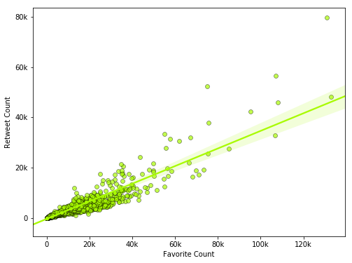

```python
fig, ax = plt.subplots(figsize=(8,6))
sb.regplot(df.fav_cnt, df.retwt_cnt,
           color='#A8FB01',
           ax=ax,
           scatter_kws={'alpha': 0.7, 'edgecolor': 'k', 'linewidth': 0.5})
plt.xlabel('Favorite Count')
plt.ylabel('Retweet Count')
plt.xticks([0,20000,40000,60000,80000,100000,120000],
           ['0','20k','40k','60k','80k','100k','120k'])
plt.yticks([0,20000,40000,60000,80000],
           ['0','20k','40k','60k','80k']);
plt.savefig('fav_vs_retwt_cnt.png')
```

#### It is obvious favorite counts and retweet counts have a positive correlation. The intensity of the counts is heavily concentrated from the begining up to 40k favorite counts, with the counts largely below the regression line.

#### Next, let's see their trends in the time period from Nov 2015 to Aug 2017.

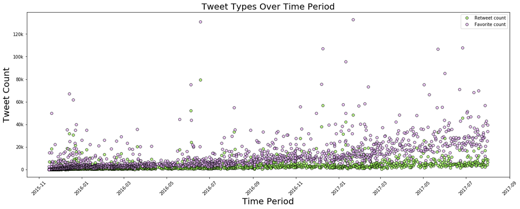

```python
period=pd.to_datetime(df.timestamp).dt.date

fig, ax = plt.subplots(figsize=(20,7))
plt.plot_date(period,df.retwt_cnt, color='#A1FE5A',
              marker='o', markeredgecolor='k', linewidth=0.5,
              alpha=0.7, label='Retweet count')
plt.plot_date(period,df.fav_cnt, color='#ECB3FF', linewidth=0.5,
              marker='o', markeredgecolor='k',
              alpha=0.7, label='Favorite count')
plt.legend()
plt.xlabel('Time Period', fontsize=20)
plt.ylabel('Tweet Count', fontsize=20)
plt.title('Tweet Types Over Time Period', fontsize=20)
plt.yticks([0,20000,40000,60000,80000,100000,120000],
           ['0','20k','40k','60k','80k','100k','120k'])
plt.xticks(rotation = 45);
plt.savefig('fav_Retwt_cnt.png')
```

#### From the begining till 2016-04, the intensity of both favorite and retweet counts is similar, although favorite counts are higher than retweet counts. This trend is even more conspicuous with the progression of time, with favorite counts steadily rising above retweet counts from around 2016-09. Interestingly, the bulk of retweet counts remains below 10k.

### 3.2 Visualization 2 and Data Insight 2

#### Let's also see the trends of favorite and retweet counts among the `dog, not dog` and `hybrid` species.

```python
# get a count of each species
df.p_class.value_counts()
```

```
dog        1194
hybrid      472
not dog     305
Name: p_class, dtype: int64
```

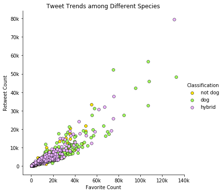

```python
if sb.__version__ <= '0.8.1':
    g=sb.pairplot(x_vars=["fav_cnt"],
                y_vars=["retwt_cnt"],
                hue="p_class",
                palette={"not dog": "#FFE608", "dog": "#A1FE5A", "hybrid": "#ECB3FF"},
                plot_kws=dict(edgecolor="k", linewidth=0.5),
                size=5.5,
                data=df);
else:
    g=sb.pairplot(x_vars=["fav_cnt"],
                y_vars=["retwt_cnt"],
                hue="p_class",
                palette={"not dog": "#FFE608", "dog": "#A1FE5A", "hybrid": "#ECB3FF"},
                plot_kws=dict(edgecolor="k", linewidth=0.5),
                height=5.5,
                data=df);
g._legend.set_title("Classification")
plt.xlabel('Favorite Count')
plt.ylabel('Retweet Count')
plt.title('Tweet Trends among Different Species')
plt.xticks([0,20000,40000,60000,80000,100000,120000,140000],
           ['0','20k','40k','60k','80k','100k','120k','140k'])
plt.yticks([0,10000,20000,30000,40000,50000,60000,70000,80000],
           ['0','10k','20k','30k','40k','50k','60k','70k','80k']);
plt.savefig('fav_Retwt_cnt_dogclass.png')
```

#### Among the 3 speicies, both favorite and retweet counts have a positive correlation. The bulk of tweets is mainly from the species of `dog` and `hybrid`, which is in line with their respective species counts - 1194 dog and 472 hybrid.

#### Given WeRateDogs is all about dogs, it is unconvincing there are tweets about `hybrid` and `not dog` species classified by the neural network dog breed classifier. Might the model be not quite refined yet? Let's take a closer look at its accuracy next.

### 3.3 Visualization 3 and Data Insight 3

#### First, take a look at the descriptive statistics on rating, favorite, retweet counts and the top 3 model confident predictions.

```python
df[['rating_numerator','rating_denominator','retwt_cnt','fav_cnt','p1_conf','p2_conf','p3_conf','p_class']].describe()
```

|  | rating_numerator | rating_denominator | retwt_cnt | fav_cnt | p1_conf | p2_conf | p3_conf |
| --- | --- | --- | --- | --- | --- | --- | --- |
| count | 1971.000000 | 1971.000000 | 1971.000000 | 1971.000000 | 1971.000000 | 1.971000e+03 | 1.971000e+03 |
| mean | 12.178985 | 10.477423 | 2784.449518 | 8949.106545 | 0.594558 | 1.345850e-01 | 6.016556e-02 |
| std | 41.607230 | 6.853275 | 4697.662893 | 12267.799790 | 0.272126 | 1.010527e-01 | 5.094156e-02 |
| min | 0.000000 | 2.000000 | 16.000000 | 81.000000 | 0.044333 | 1.011300e-08 | 1.740170e-10 |
| 25% | 10.000000 | 10.000000 | 628.500000 | 1997.000000 | 0.363091 | 5.339800e-02 | 1.608055e-02 |
| 50% | 11.000000 | 10.000000 | 1367.000000 | 4147.000000 | 0.587764 | 1.173970e-01 | 4.944380e-02 |
| 75% | 12.000000 | 10.000000 | 3239.000000 | 11402.500000 | 0.847827 | 1.955655e-01 | 9.153815e-02 |
| max | 1776.000000 | 170.000000 | 79515.000000 | 132810.000000 | 1.000000 | 4.880140e-01 | 2.734190e-01 |

#### Let's check the top 10 dog ratings along with a visual

```python
df.rating_numerator.value_counts()
```

```
12.00      446
10.00      417
11.00      392
13.00      253
9.00       150
8.00        95
7.00        52
14.00       33
6.00        32
5.00        32
3.00        19
4.00        16
2.00         9
1.00         5
60.00        1
24.00        1
99.00        1
1776.00      1
13.50        1
11.27        1
165.00       1
11.26        1
0.00         1
84.00        1
9.75         1
45.00        1
88.00        1
144.00       1
44.00        1
121.00       1
204.00       1
50.00        1
80.00        1
420.00       1
Name: rating_numerator, dtype: int64
```

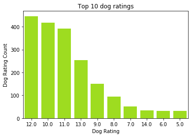

```python
ratings=df.rating_numerator.value_counts().index[0:10]
rating_cnts=df.rating_numerator.value_counts().values[0:10]

sb.barplot(x=ratings, y=rating_cnts, order = ratings, color='#A8FB01')
plt.xlabel('Dog Rating')
plt.ylabel('Dog Rating Count')
plt.title('Top 10 dog ratings');
plt.savefig('top10_dog_rating.png')
```

#### Also top 10 dog breeds with a visual

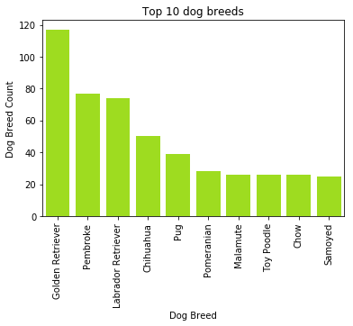

```python
#top 10 dog breeds
breeds=df[df.p_class=='dog'].p1.value_counts().index[0:10]
breed_cnts=df[df.p_class=='dog'].p1.value_counts().values[0:10]

sb.barplot(x=breeds, y=breed_cnts, order = breeds, color='#A8FB01')
plt.xlabel('Dog Breed')
plt.ylabel('Dog Breed Count')
plt.title('Top 10 dog breeds')
plt.xticks(rotation = 90);
plt.savefig('top10_dog_breeds.png')
```